# minimo_lagrange

## Minimizzazione di una funzione con l'imposizione di vincoli

Vediamo qui un esempio di come sia possibile, in Python, trovare la posizione del minimo di una funzione imponendo dei *constraints* a cui devono soddisfare le variabili indipendenti.

Importiamo le librerie di Python di cui necessitiamo; alcune come matplotlib servono per le rappresentazioni grafiche, altre sono necessarie per il calcolo vero e proprio. In particolare, dalla libreria *scipy.optimize* importiamo la funzione *minimize* che implementa vari metodi per la minimizzazione di funzioni.

```python
import matplotlib.pyplot as plt
from matplotlib import cm
from mpl_toolkits.mplot3d import axes3d
import numpy as np
from scipy.optimize import minimize
```

Lanciamo il *magic command* seguente, per poter avere interattività con la grafica che rappresentiamo all'interno del notebook (i *magic command* sono quelli preceduti dal simbolo %). Tecnicamente *%matplotlib notebook* specifica il *backend* di [matplotlib](https://matplotlib.org/) che raccoglie tutte le funzioni per la grafica

```python
%matplotlib notebook
```

Definiamo adesso la funzione di cui vogliamo determinare il minimo (il minimo locale entro una certa regione); la nostra funzione, che chiamiamo *function* sia:

$$z=f(x,y)=\frac{1}{3}x^3+\frac{2}{3}y^3-x^2+4y^2-4x$$

Notiamo che, in vista dell'uso del metodo *minimize*, poniamo come argomento di *function* non direttamente una coppia di valori x e y (2 argomenti della funzione), ma un singolo argomento *x_var* che sarà una coppia di valori (x,y); la funzione *function* medesima si preccuperà di *spacchettare x_var* nelle due variabili x e y.

```python
def function(x_var):
    x=x_var[0]
    y=x_var[1]
    return (1/3)*x**3+(2/3)*y**3-x**2+4*y**2-4*x
```

Non è difficile per questa funzione determinare i punti di stazionarietà in modo analitico, tuttavia lo facciamo qui per via numerica.

Ai fini di una rappresentazione grafica della funzione, ci costruiamo una griglia di punti x, y sui quali valutare la funzione. Per questo usiamo la funzione *linspace* di Numpy (*np.linspace*) per crearci delle liste di valori x e y con i quali poi definiremo la griglia attraverso la funzione *meshgrid*.

*meshgrid* ci restituisce la corrispondente griglia di punti.

```python
x=np.linspace(-2,5,50)
y=np.linspace(-5,2,50)
x_grid,y_grid=np.meshgrid(x,y)
```

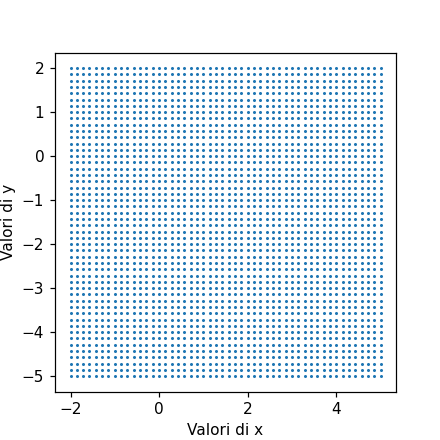

```python
plt.figure(figsize=[4,4])
plt.scatter(x_grid,y_grid,s=1)
plt.xlabel("Valori di x")
plt.ylabel("Valori di y")
```

Calcoliamo adesso i valori della funzione sulla griglia di punti e salviamoli nella variabile z_grid

```python
z_grid=function([x_grid,y_grid])
```

Rappresentiamo graficamente la funzione. Il codice che segue costruisce la superficie $z=f(x,y)$ e ne fa anche le proiezioni sui piani coordinati:

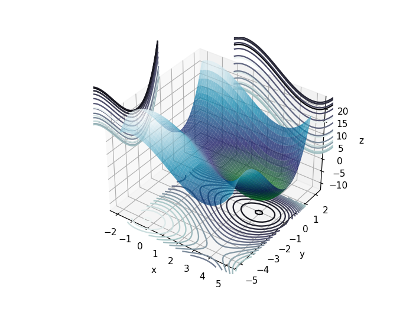

```python
fig = plt.figure()
ax = fig.add_subplot(111, projection='3d')
ax.plot_surface(x_grid,y_grid,z_grid, rstride=1, cstride=1, alpha=0.7, cmap=cm.ocean)
cset = ax.contour(x_grid, y_grid, z_grid, 20, zdir='z', offset=np.min(z_grid)-7, cmap=cm.bone)
cset = ax.contour(x_grid, y_grid, z_grid, 20, zdir='x', offset=-5,cmap=cm.bone)
cset = ax.contour(x_grid, y_grid, z_grid, 20, zdir='y', offset=5,cmap=cm.bone)
ax.set_xlabel("x")
ax.set_ylabel("y")
ax.set_zlabel("z")
```

Passiamo alla ricerca del minimo della funzione usando la funzione *minimize*. Come input questa funzione accetta:

- il nome della funzione da minimizzare (*function*)
- una lista x0 di valori iniziali (*ragionevoli*) da cui partire per la minimizzazione
- il metodo scelto per la ricerca del minimo: usiamo 'slsqp' perchè è quello utile quando introdurremo un vincolo a cui devono soddisfare x e y
- mettiamo anche dei valori limite (*bounds*) sugli intervalli di x e y entro i quali fare la ricerca del minimo

La documentazione completa per *minimize* si trova [qui](https://docs.scipy.org/doc/scipy/reference/generated/scipy.optimize.minimize.html#scipy.optimize.minimize)

I risultati sono posti nella *variabile res* che raccoglie alcune informazioni sull'intero processo di minimizzazione. La variabile *res* è in realtà l'istanza di una *classe* che ha vari attributi; per esempio *res.x* è un array contenente i valori di x e y a cui è stato trovato il minimo

```python
x0=(4,-1)
bound=((0,5),(-4,0))
res=minimize(function,x0,method='slsqp',bounds=bound)
print(res)
```

```
 message: Optimization terminated successfully
 success: True
  status: 0
     fun: -12.120226494906921
       x: [ 3.236e+00 -9.701e-15]
     nit: 5
     jac: [-9.302e-04 -1.192e-07]
    nfev: 16
    njev: 5
```

```python
print("Posizione del minimo\nx: %4.3f; y: %4.3f" % (res.x[0],res.x[1]))
print("Valore della funzione nel minimo: %5.3f" % function(res.x))
print("Valore del minimo della funzione restituito da minimize: %5.3f" % res.fun)
```

```
Posizione del minimo
x: 3.236; y: -0.000
Valore della funzione nel minimo: -12.120
Valore del minimo della funzione restituito da minimize: -12.120
```

Il minimo della funzione calcolata numericamente sulla nostra griglia (che potrebbe non coincidere con il minimo locale trovato da *minimize*) è in questo caso molto vicino al valore trovato da *minimize*:

```python
np.min(z_grid).round(3)
```

```
-12.115
```

Volendo conoscere i valori di x e y al minimo valutato sulla griglia, usiamo il codice seguente (alquanto *misterioso*)

```python
iy,ix=np.unravel_index(z_grid.argmin(), z_grid.shape)
print("x e y: %5.3f, %5.3f " %(x[ix],y[iy]))
```

```
x e y: 3.286, 0.000
```

Come verifica, calcoliamo la funzione nei due punti x e y:

```python
print("Valore della funzione: %5.3f " % function([x[ix],y[iy]]))
```

```
Valore della funzione: -12.115
```

Adesso definiamo un vincolo a cui devono soddisfare le due variabili indipendenti. Poniamo:

$$x + 2y =2$$

Vogliamo in altre parole determinare il minimo della funzione *function* lungo la retta di equazione

$$y=-\frac{1}{2}x+1$$

Per far questo, cominciamo con lo scrivere l'equazione del vincolo nella forma

$$c(x,y)=0 \rightarrow x+2y-2=0$$

Definiamo quindi un *dizionario* Python con il codice seguente che implementa l'equazione del vincolo nella forma di funzione *lambda* (funzione *anonima* a cui non viene dato un nome specifico); il dizionario *con* specifica che il vincolo dato dalla funzione *lambda* è del tipo *funzione* ('fun') e che si tratta di un vincolo corrispondente a un'uguaglianza $c(x,y)=0\ $ ('eq'); l'alternativa sarebbe una disuguaglianza 'ineq' da usarsi se, per esempio, volessimo imporre la disuguaglianza $c(x,y)>0$.

```python
con={'type': 'eq', 'fun': lambda x: x[0]+2*x[1]-2}
```

A questo punto usiamo ancora la funzione *minimize* passando anche l'argomento opzionale *constraints* a cui attribuiamo il valore *con*:

```python
res=minimize(function, x0, method='slsqp', constraints=con, bounds=bound)
```

```python
res
```

```
 message: Optimization terminated successfully
 success: True
  status: 0
     fun: -11.135121633539388
       x: [ 2.861e+00 -4.303e-01]
     nit: 5
     jac: [-1.538e+00 -3.072e+00]
    nfev: 15
    njev: 5
```

```python
print("Posizione del minimo\nx: %4.2f; y: %4.2f" % (res.x[0],res.x[1]))
print("Valore della funzione nel minimo: %5.3f" % function(res.x))
```

```
Posizione del minimo
x: 2.86; y: -0.43
Valore della funzione nel minimo: -11.135
```

Controlliamo che il vincolo sia soddisfatto:

```python
c=res.x[0]+2*res.x[1]
print("Valore del vincolo: %5.3f " % c)
```

```
Valore del vincolo: 2.000
```

che in effetti corrisponde a quanto avevamo richiesto!

Possiamo visualizzare il risultato graficamente. La figura seguente mostra la funzione *function* rappresentata nel piano x,y con le linee di livello. La linea tratteggiata rappresenta il vincolo: il minimo è cercato lungo la retta tratteggiata. L'asterisco in rosso mostra la posizione del minimo vincolato che, appunto, giace sulla retta.

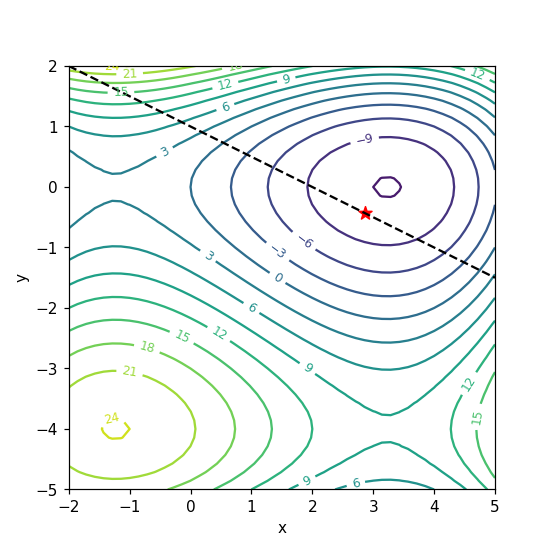

```python
yc=-0.5*x+1  # retta che rappresenta il vincolo

plt.figure(figsize=[5,5])

# linee di livello della funzione "function"
cont=plt.contour(x_grid,y_grid,z_grid,12)
plt.clabel(cont, fontsize=8)

# retta del vincolo
plt.plot(x,yc,"k--")

# posizione del minimo
plt.scatter(res.x[0],res.x[1],marker="*",c="r",s=80)
plt.xlabel("x")
plt.ylabel("y")
plt.show()
```

Alternativamente possiamo rappresentare l'andamento della funzione $f(x,y)$ lungo la retta $y=-1/2\ x + 1$. La posizione del minimo è rappresentata dall'asterisco in rosso.

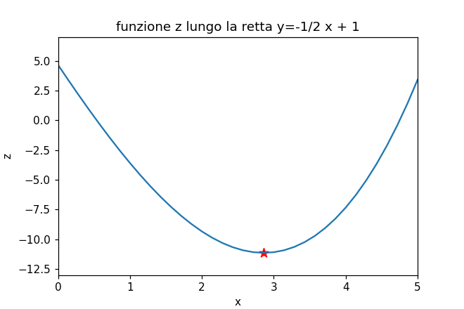

```python
# calcolo della funzione lungo la retta yc
zc=function([x,yc])

plt.figure(figsize=[6,4])
plt.plot(x,zc)
plt.xlim([0,5])
plt.ylim([-13,7])
plt.scatter(res.x[0],res.fun,marker="*",c="r",s=80)
plt.xlabel("x")
plt.ylabel("z")
plt.title("funzione z lungo la retta y=-1/2 x + 1")
plt.show()
```